**Project:**P1330White **PI:**Alice White  
**Prepared By:**Caroline Ledbetter  
**Date:** 04/08/2020

# Methods

## Data

Data were collected from 1998-2016 from NORS. Food-borne outbreaks were grouped into categories based on the food source as identified in NORS. Outbreaks missing IFSAC information, those caused by multiple sources, unclassified outbreaks, outbreaks of undetermined source and outbreaks from a source other than animal or plant were removed. Food-borne outbreak caused by dairy, eggs, fruits, meat, poultry, or vegetables were included. Food-borne outbreaks caused by other sources were excluded. Non food-borne outbreaks caused by animal contact were included. (Fig 1)  
The final analysis data was split into training (75%) and test (25%) stratified by outbreak source to ensure balance. A validation data set consisting of 2017 outbreak data was used to evaluate the final selected model.

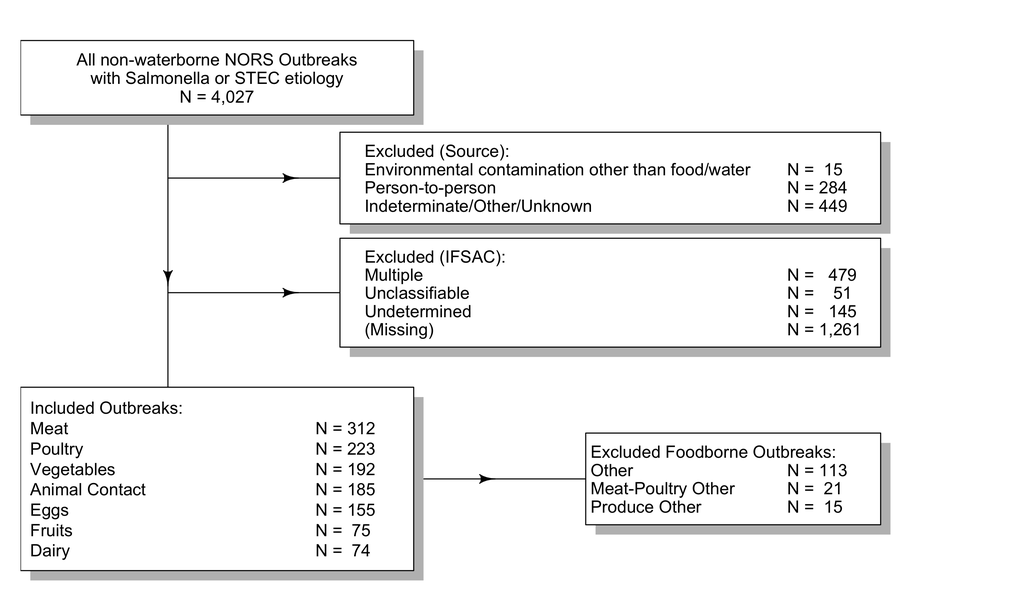

Fig.1 Cohort Flow Chart

## Predictors

The month of the first illness, the geography of the outbreak (multi state, multi county, single county), the etiology of the outbreak (STEC or Salmonella serotype) and the gender and ages of cases were used as predictors. Missing predictors were imputed using k-nearest neighbors using the training data.

*Gender and Age*  
The number of female cases as a proportion of cases whose gender was known was used for predicting. If gender was unknown for all cases, the predictor was missing. The number of cases for each age group (under 1, 1 to 4, 5 to 19, 20 to 49, 50 plus) as a proportion of cases whose age was known was used for predicting. If age was unknown for all cases, the age predictors were missing.

*Salmonella Serotypes*  
Only serotypes with ten or more outbreaks were included as is. Salmonella serotypes with less than ten outbreaks but more than three were clustered into three groups based on there association with plant or animal outbreaks using logistic regression. Serotypes with three or fewer outbreaks were categorized as rare. Missing Salmonella serotypes were treated as missing.

## Model Selection

We selected six algorithmic methods for prediction based on their ability to predict multiple class probabilities well - adaptive boosting classification trees (AdaBoost.M1), classification and regression trees (CART), weighted k nearest neighbors (knn), boosted trees (using xgboost), random forest (using ranger) and multivariate adaptive regression splines (MARS). A non-informative model that uses no information from predictors was also generated for comparison purposes. The final model was chosen based on Brier Scores (a measure of the difference in the predicted probability and the actual event). All analysis was done in R version 3.6.1 (2019-07-05). Data cleaning was done using the tidyverse. rsample v(0.0.5) and recipes v(0.1.9) (part of tidymodels) were used for data splitting, imputation and preprocessing. The parsnip v(0.0.4.9000) (null model), adabag v(4.2) (Adaboost.M1), C50 v(0.1.2) (CART), kknn v(1.3.1) (weighted knn), xgboost v(0.90.0.2) (boosted trees), and ranger v(0.11.2) (random forest) packages were used. The caret Package v(6.0.84) was used for tuning and test set prediction. The final model was selected based on the brier score of the test set. The brier score is a measurement of the accuracy of probabilistic predictions of mutually exclusive outcomes. It is the mean of the square of the differences between the predicted probability and the observed outcome (equal to zero if the outcome did not occur, one if it did). (Fig 2)
$$BS = \frac{1}{N} \sum^{N}_{t=1} \sum^{N}_{i=1} (f_{ti} - o_{ti})^2$$
where $f$ is the predicted probability of the category for an event, $o$ is the observed outcome for a category for an event, $R$ is number of possible categories and $N$ is the total number of observed outcomes.

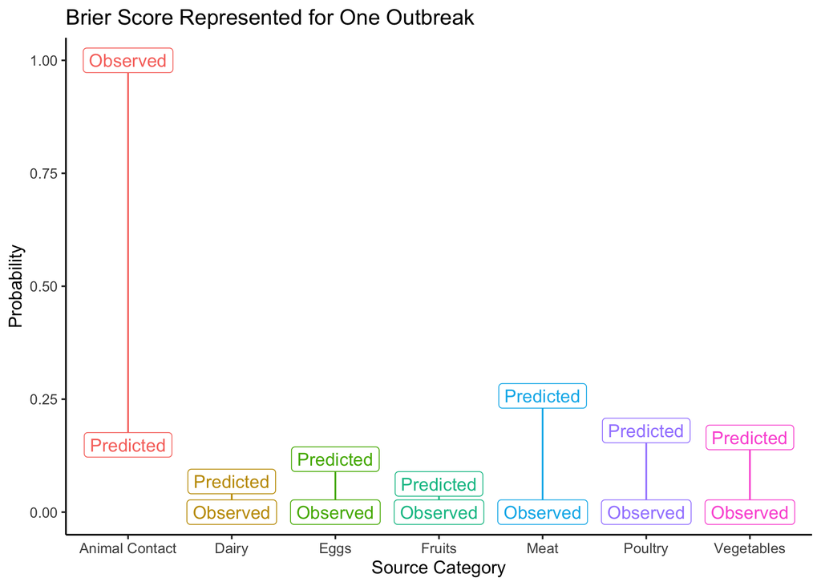

Figure 2. Graphical Representation of Brier Score for One Outbreak

# Results

There were 4,027 non-waterborne outbreaks in the NORS database. 748 outbreaks that were not food-borne or animal contact were excluded. 1,936 food-borne outbreaks were excluded because they did not have a single identifiable food source. The final data set included 1,216 outbreaks that were identified as dairy, eggs, fruits, meat, poultry, vegetables and animal contact.

Table 1. Outbreak Characteristics by Source

|  |  | Animal Contact N= 185 | Dairy N= 74 | Eggs N= 155 | Fruits N= 75 | Meat N= 312 | Poultry N= 223 | Vegetables N= 192 | Other N= 149 |
| --- | --- | --- | --- | --- | --- | --- | --- | --- | --- |
| Agent | Escherichia | 44(24) | 33(45) | – | 17(23) | 144(46) | 3(1) | 61(32) | 31(21) |
|  | Salmonella | 141(76) | 41(55) | 155(100) | 58(77) | 168(54) | 220(99) | 131(68) | 118(79) |
| Season | Winter | 65(35) | 15(20) | 27(17) | 8(11) | 41(13) | 27(12) | 37(19) | 24(16) |
|  | Spring | 50(27) | 17(23) | 37(24) | 27(36) | 104(33) | 61(27) | 57(30) | 39(26) |
|  | Summer | 42(23) | 25(34) | 59(38) | 24(32) | 112(36) | 73(33) | 50(26) | 55(37) |
|  | Fall | 28(15) | 17(23) | 32(21) | 16(21) | 55(18) | 62(28) | 48(25) | 31(21) |
| Geography | Multi County | 25(14) | 29(39) | 12(8) | 12(16) | 49(16) | 14(6) | 34(18) | 9(6) |
|  | Multi State | 71(38) | 8(11) | 4(3) | 33(44) | 55(18) | 14(6) | 97(51) | 33(22) |
|  | Single County | 85(46) | 37(50) | 137(88) | 28(37) | 206(66) | 194(87) | 60(31) | 106(71) |
|  | Missing | 4(2) | – | 2(1) | 2(3) | 2(1) | 1(0) | 1(1) | 1(1) |
| Total Cases | Mean (Sd) | 31.24(56.14) | 24.59(36.94) | 36.94(158.52) | 54.28(119.66) | 22.46(38.42) | 26.18(58.56) | 56.57(139.31) | 47.68(128.48) |
| Percent Male | Mean (Sd) | 42.13(22.87) | 47.52(21.74) | 49.81(23.39) | 36.21(17.70) | 50.61(23.51) | 49.07(26.59) | 37.94(19.08) | 47.05(21.39) |
| Percent Female | Mean (Sd) | 57.87(22.87) | 52.48(21.74) | 50.19(23.39) | 63.79(17.70) | 49.39(23.51) | 50.93(26.59) | 62.06(19.08) | 52.95(21.39) |
| Percent Under 1yr | Mean (Sd) | 9.03(13.25) | 1.60(3.53) | 0.68(4.63) | 1.73(3.60) | 0.76(4.06) | 0.70(3.16) | 0.69(2.43) | 1.32(6.58) |
| Percent 1yr to 4yr | Mean (Sd) | 27.27(27.26) | 21.04(21.40) | 2.77(6.73) | 11.37(16.50) | 7.55(16.47) | 5.67(12.56) | 4.63(11.09) | 6.93(14.25) |
| Percent 20yr to 49yr | Mean (Sd) | 20.30(21.88) | 27.14(25.51) | 46.73(30.64) | 25.71(20.86) | 41.72(29.70) | 50.48(30.11) | 50.53(22.96) | 49.42(29.69) |
| Percent 5yr to 19yr | Mean (Sd) | 31.29(28.93) | 36.56(25.26) | 17.12(24.49) | 25.91(25.29) | 27.35(28.99) | 19.43(25.62) | 19.71(18.48) | 19.30(22.77) |
| Percent 50yr or older | Mean (Sd) | 12.10(17.68) | 13.65(19.15) | 32.70(31.06) | 35.29(31.76) | 22.63(24.66) | 23.73(28.07) | 24.44(20.83) | 23.04(26.67) |
| Percent Hospitalized | Mean (Sd) | 0.28(0.26) | 0.31(0.29) | 0.18(0.24) | 0.27(0.19) | 0.31(0.30) | 0.23(0.28) | 0.27(0.23) | 0.25(0.25) |
| Length (in days) of Outbreak | Mean (Sd) | 44.97(127.00) | 36.47(60.24) | 8.77(20.34) | 7.23(11.26) | 7.48(19.54) | 5.88(42.01) | 10.47(18.43) | 8.25(15.21) |

Final selected tuning parameters are shown in table 2. All models performed better than the null model on the test set (table 3). Calibration curves are shown in figure 3.

Table 2. Tuning Parameters

| Model | Parameters |
| --- | --- |
| Random Forest | mtry = 2; split rule = gini; min node size = 1 |
| Weighted k-nearest neighbors | k = 44 |
| Multivariate Adaptive Regression Spline | degree = 2; nprune = 18 |
| Boosted Trees | eta = 0.3; max depth = 6; gamma = 0 |
| CART | trials = 20; model type = ‘rules’; no winnowing |
| Adaboost.M1 | mfinal = 9, max depth = 1, coefficient type = ‘Zhu’ |

Table 3. Brier Scores for each model

| Model | Brier Score |
| --- | --- |
| Random Forest | 0.096 |
| Boosted Trees | 0.098 |
| Weighted k-Nearest Neighbors | 0.099 |
| Multivariate Adaptive Regression Spline | 0.101 |
| CART | 0.105 |
| Adaboost.M1 | 0.111 |
| Null | 0.118 |

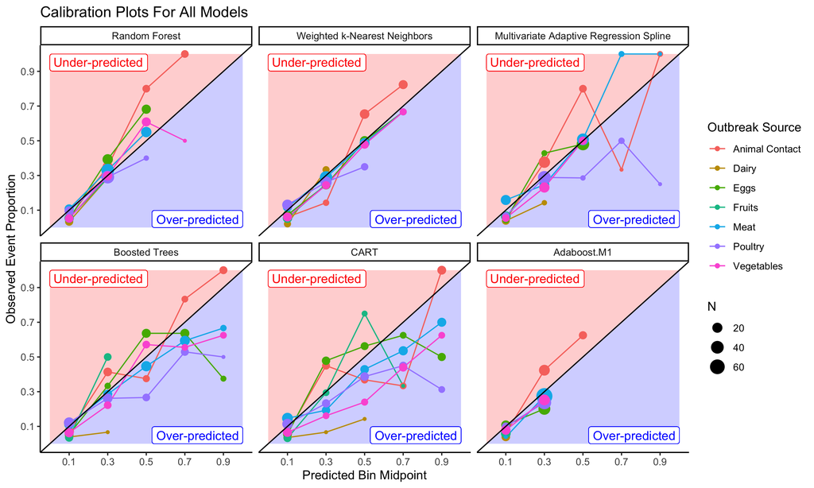

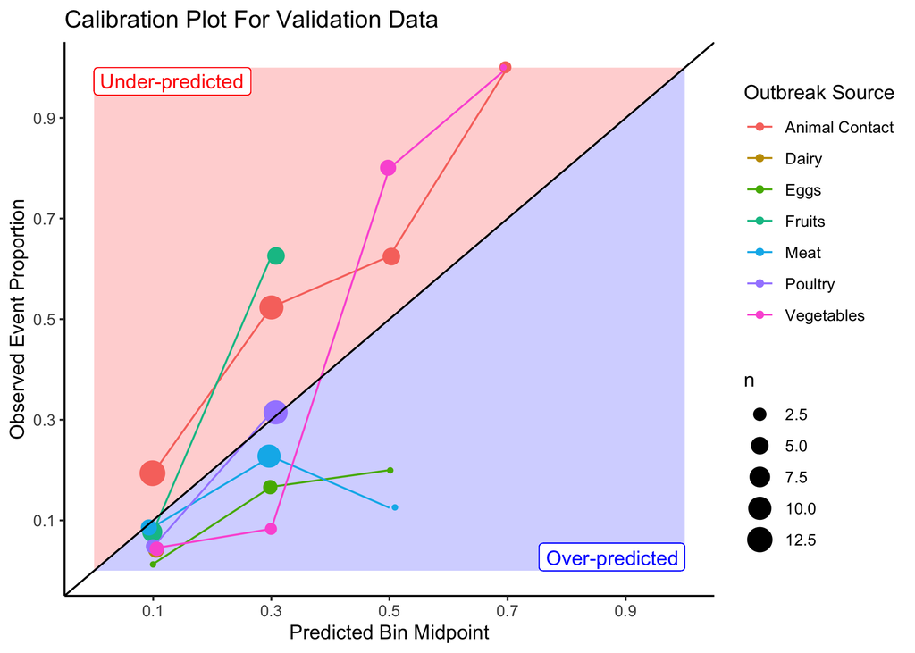

Overall, the correct outbreak was in the top two predicted for 60 (61%) of outbreaks. The percentage of outbreaks where the correct category was in the top two predictions by actual outbreak source is shown in figure 5.

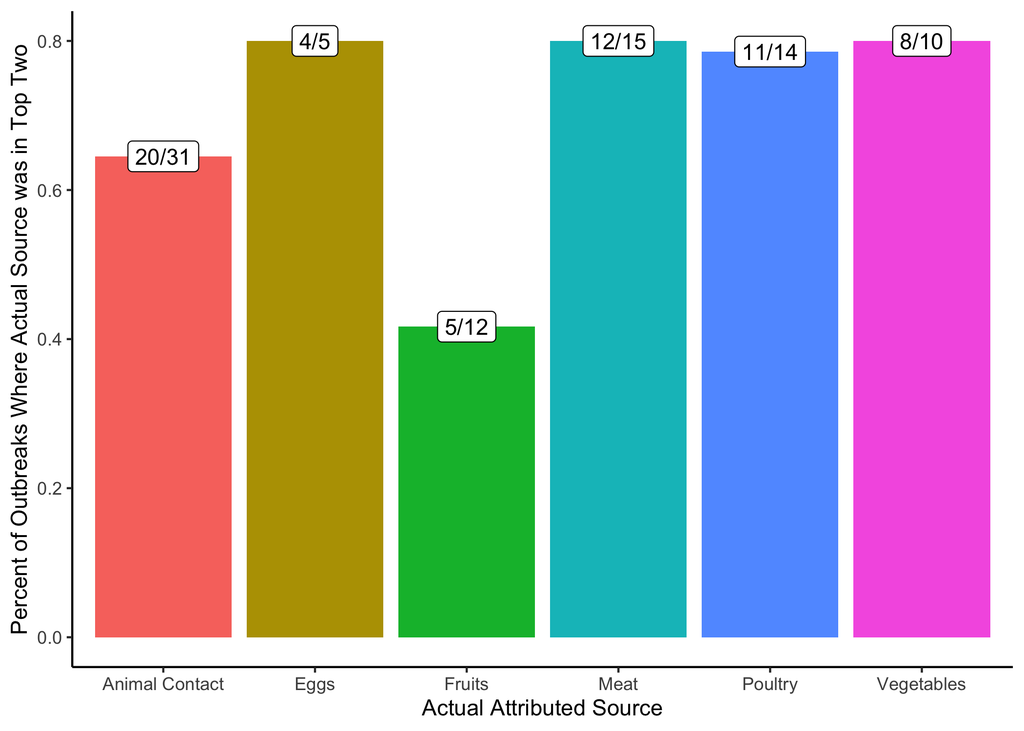

| Salmonella Serotype | Animal Contact | Meat | Poultry | Meat-Poultry Other | Eggs | Dairy | Vegetables | Fruits | Produce Other | Other |
| --- | --- | --- | --- | --- | --- | --- | --- | --- | --- | --- |
| Braenderup | 7 | 2 | 7 | – | 1 | – | 7 | 2 | – | 2 |
| Enteritidis | 10 | 22 | 56 | 5 | 123 | 1 | 16 | 5 | 2 | 15 |
| Group B | – | 2 | 6 | 1 | 2 | – | – | 1 | 1 | – |
| Hadar | 7 | – | 8 | – | 1 | – | – | – | – | – |
| Heidelberg | 2 | 2 | 25 | – | 10 | – | – | 1 | – | 7 |
| I 4,[5],12:i:- | 12 | 12 | 5 | 1 | – | 1 | 2 | – | 1 | 2 |
| Infantis | 8 | 10 | 1 | – | – | – | 1 | – | – | 4 |
| Javiana | 1 | 2 | 4 | – | – | – | 13 | 4 | – | 3 |
| Montevideo | 9 | 4 | 3 | – | – | 3 | 2 | – | – | 3 |
| Muenchen | 3 | 1 | 6 | – | – | – | 4 | 3 | – | 1 |
| Newport | 1 | 17 | 10 | – | – | 9 | 27 | 8 | 2 | 3 |
| Paratyphi B | 4 | – | – | – | – | – | 2 | – | – | 4 |
| Poona | 6 | – | – | – | – | – | 1 | 4 | – | – |
| Saintpaul | 1 | 1 | 5 | – | 1 | 2 | 10 | 3 | 1 | 1 |
| Thompson | 3 | 3 | 4 | – | 1 | – | 3 | 1 | – | 2 |
| Typhimurium | 32 | 29 | 22 | 3 | 5 | 18 | 11 | 7 | 1 | 10 |
| Typhimurium var Cope | 1 | 5 | 4 | 1 | – | – | 1 | – | – | – |
| Uganda | 1 | 8 | – | – | – | – | – | 1 | – | – |
| Mixed | 1 | 10 | 5 | 1 | 2 | – | 6 | 5 | – | 6 |
| Rare | 13 | 18 | 12 | – | 1 | 4 | 10 | 9 | – | 16 |
| Other | 4 | 12 | 29 | 3 | 8 | 3 | 5 | 1 | – | 6 |
| STEC | 44 | 144 | 3 | 6 | – | 33 | 61 | 17 | 6 | 19 |
| – | 15 | 8 | 8 | – | – | – | 10 | 3 | 1 | 9 |

Table 1. Outbreak Characteristics by Source

|  |  | Animal Contact N= 31 | Dairy N= 4 | Eggs N= 5 | Fruits N= 12 | Meat N= 15 | Other N= 7 | Poultry N= 14 | Vegetables N= 10 |
| --- | --- | --- | --- | --- | --- | --- | --- | --- | --- |
| Agent | Escherichia | 10(32) | 1(25) | – | – | 2(13) | 2(29) | – | 4(40) |
|  | Salmonella | 21(68) | 3(75) | 5(100) | 12(100) | 13(87) | 5(71) | 14(100) | 6(60) |
| Season | Spring | 8(26) | 3(75) | 1(20) | 3(25) | 2(13) | – | 5(36) | 1(10) |
|  | Summer | 9(29) | – | 1(20) | 5(42) | 11(73) | 3(43) | 1(7) | 4(40) |
|  | Winter | 14(45) | – | 1(20) | 3(25) | 1(7) | 4(57) | 3(21) | 2(20) |
|  | Fall | – | 1(25) | 2(40) | 1(8) | 1(7) | – | 5(36) | 3(30) |
| Geography | Multi State | 14(45) | 1(25) | 1(20) | 10(83) | – | 3(43) | 1(7) | 6(60) |
|  | Single County | 17(55) | 3(75) | 4(80) | 1(8) | 12(80) | 2(29) | 9(64) | 3(30) |
|  | Missing | – | – | – | 1(8) | 1(7) | 1(14) | 3(21) | – |
|  | Multi County | – | – | – | – | 2(13) | 1(14) | 1(7) | 1(10) |
| Total Cases | Mean (Sd) | 43.161(73.56) | 8.250(5.12) | 16.200(16.57) | 38.333(57.10) | 11.133(11.75) | 40.714(70.55) | 63.000(145.18) | 39.300(45.10) |
| Percent Male | Mean (Sd) | 52.219(18.93) | 49.482(40.25) | 28.683(19.61) | 48.505(14.58) | 48.619(31.27) | 39.725(20.09) | 58.976(27.68) | 36.023(9.34) |
| Percent Female | Mean (Sd) | 47.781(18.93) | 50.518(40.25) | 71.317(19.61) | 51.495(14.58) | 51.381(31.27) | 60.275(20.09) | 41.024(27.68) | 63.977(9.34) |
| Percent Under 1yr | Mean (Sd) | 5.801(9.42) | 1.785(3.57) | 0.000(0.00) | 3.342(3.90) | 8.579(28.80) | 0.071(0.19) | 3.846(13.87) | 0.477(1.26) |
| Percent 1yr to 4yr | Mean (Sd) | 24.622(32.20) | 18.118(16.55) | 1.135(2.27) | 14.423(19.88) | 1.131(2.67) | 5.055(12.93) | 6.410(16.01) | 1.885(2.47) |
| Percent 20yr to 49yr | Mean (Sd) | 24.657(24.24) | 18.961(13.19) | 40.499(19.00) | 27.447(21.39) | 56.382(33.77) | 58.386(24.32) | 54.108(25.25) | 37.449(13.71) |
| Percent 5yr to 19yr | Mean (Sd) | 26.077(31.89) | 34.816(26.54) | 2.273(4.55) | 18.114(21.03) | 16.352(28.35) | 23.363(19.37) | 11.593(15.86) | 23.699(22.06) |
| Percent 50yr or older | Mean (Sd) | 18.843(23.47) | 26.319(14.82) | 56.093(16.95) | 36.674(24.10) | 17.557(17.57) | 13.124(12.34) | 24.042(20.73) | 36.490(21.42) |
| Percent Hospitalized | Mean (Sd) | 0.295(0.25) | 0.189(0.17) | 0.313(0.25) | 0.284(0.17) | 0.238(0.24) | 0.234(0.18) | 0.135(0.24) | 0.337(0.30) |

```
## ranger variable importance
##
##   only 20 most important variables shown (out of 31)
##
##                           Overall
## serogroupEnteritidis      100.000
## serogroupSTEC              94.558
## geographysingle_county     72.438
## percent_age20to49          68.055
## geographymulti_state       47.965
## percent_age_under1         45.847
## percent_age1to4            33.925
## percent_age50plus          30.775
## percent_age5to19           30.130
## percent_female             26.375
## month                      20.068
## serogroupHeidelberg         8.324
## serogroupI 4,[5],12:i:-     6.423
## serogroupPrimarily Animal   4.927
## serogroupNewport            3.994
## serogroupUganda             3.808
## serogroupJaviana            3.410
## serogroupInfantis           2.959
## serogroupPrimarily Plant    2.945
## serogroupSaintpaul          2.404
```